# ExtraaLearn Project

*Marks: 60*

## Context

The EdTech industry has been surging in the past decade immensely, and according to a forecast, the Online Education market would be worth $286.62bn by 2023 with a compound annual growth rate (CAGR) of 10.26% from 2018 to 2023. The modern era of online education has enforced a lot in its growth and expansion beyond any limit. Due to having many dominant features like ease of information sharing, personalized learning experience, transparency of assessment, etc, it is now preferable to traditional education.

In the present scenario due to the Covid-19, the online education sector has witnessed rapid growth and is attracting a lot of new customers. Due to this rapid growth, many new companies have emerged in this industry. With the availability and ease of use of digital marketing resources, companies can reach out to a wider audience with their offerings. The customers who show interest in these offerings are termed as leads. There are various sources of obtaining leads for Edtech companies, like

- The customer interacts with the marketing front on social media or other online platforms.
- The customer browses the website/app and downloads the brochure
- The customer connects through emails for more information.

The company then nurtures these leads and tries to convert them to paid customers. For this, the representative from the organization connects with the lead on call or through email to share further details.

## Objective

ExtraaLearn is an initial stage startup that offers programs on cutting-edge technologies to students and professionals to help them upskill/reskill. With a large number of leads being generated regularly, one of the issues faced by ExtraaLearn is to identify which of the leads are more likely to convert so that they can allocate resources accordingly. You, as a data scientist at ExtraaLearn, have been provided the leads data to:

- Analyze and build an ML model to help identify which leads are more likely to convert to paid customers,
- Find the factors driving the lead conversion process
- Create a profile of the leads which are likely to convert

## Data Description

The data contains the different attributes of leads and their interaction details with ExtraaLearn. The detailed data dictionary is given below.

**Data Dictionary**

- ID: ID of the lead
- age: Age of the lead
- current_occupation: Current occupation of the lead. Values include 'Professional','Unemployed',and 'Student'
- first_interaction: How did the lead first interact with ExtraaLearn. Values include 'Website', 'Mobile App'
- profile_completed: What percentage of the profile has been filled by the lead on the website/mobile app. Values include Low - (0-50%), Medium - (50-75%), High (75-100%)
- website_visits: How many times has a lead visited the website
- time_spent_on_website: Total time spent on the website
- page_views_per_visit: Average number of pages on the website viewed during the visits.
- last_activity: Last interaction between the lead and ExtraaLearn.
  - Email Activity: Seeking for details about the program through email, Representative shared information with a lead like a brochure of program, etc
  - Phone Activity: Had a Phone Conversation with a representative, Had conversation over SMS with a representative, etc
  - Website Activity: Interacted on live chat with a representative, Updated profile on the website, etc
- print_media_type1: Flag indicating whether the lead had seen the ad of ExtraaLearn in the Newspaper.
- print_media_type2: Flag indicating whether the lead had seen the ad of ExtraaLearn in the Magazine.
- digital_media: Flag indicating whether the lead had seen the ad of ExtraaLearn on the digital platforms.
- educational_channels: Flag indicating whether the lead had heard about ExtraaLearn in the education channels like online forums, discussion threads, educational websites, etc.
- referral: Flag indicating whether the lead had heard about ExtraaLearn through reference.
- status: Flag indicating whether the lead was converted to a paid customer or not.

### **Please read the instructions carefully before starting the project.**

This is a commented Jupyter IPython Notebook file in which all the instructions and tasks to be performed are mentioned.

- Blanks '**___**' are provided in the notebook that needs to be filled with an appropriate code to get the correct result. With every '**___**' blank, there is a comment that briefly describes what needs to be filled in the blank space.
- Identify the task to be performed correctly, and only then proceed to write the required code.
- Fill the code wherever asked by the commented lines like "# write your code here" or "# complete the code". Running incomplete code may throw error.
- Please run the codes in a sequential manner from the beginning to avoid any unnecessary errors.
- Add the results/observations (wherever mentioned) derived from the analysis in the presentation and submit the same.

```python
import warnings

warnings.filterwarnings("ignore")
from statsmodels.tools.sm_exceptions import ConvergenceWarning

warnings.simplefilter("ignore", ConvergenceWarning)

import pandas as pd
import numpy as np

from sklearn.model_selection import train_test_split

import matplotlib.pyplot as plt
import seaborn as sns

pd.set_option("display.max_columns", None)
pd.set_option("display.max_rows", 200)
pd.set_option("display.float_format", lambda x: "%.5f" % x)

import statsmodels.stats.api as sms
from statsmodels.stats.outliers_influence import variance_inflation_factor
import statsmodels.api as sm
from statsmodels.tools.tools import add_constant
from sklearn.linear_model import LogisticRegression
from sklearn.tree import DecisionTreeClassifier
from sklearn.metrics import confusion_matrix
from sklearn import tree

from sklearn.model_selection import GridSearchCV


from sklearn.metrics import (
    f1_score,
    accuracy_score,
    recall_score,
    precision_score,
    confusion_matrix,
    roc_auc_score,
    plot_confusion_matrix,
    precision_recall_curve,
    roc_curve,
    make_scorer,
)
```

## Import Dataset

```python
learn = pd.read_csv("ExtraLearn..csv")
```

```python
data = learn
```

### View the first and last 5 rows of the dataset

```python
data.head(5)
```

|  | ID | age | current_occupation | first_interaction | profile_completed | website_visits | time_spent_on_website | page_views_per_visit | last_activity | print_media_type1 | print_media_type2 | digital_media | educational_channels | referral | status |
| --- | --- | --- | --- | --- | --- | --- | --- | --- | --- | --- | --- | --- | --- | --- | --- |
| 0 | EXT001 | 57 | Unemployed | Website | High | 7 | 1639 | 1.86100 | Website Activity | Yes | No | Yes | No | No | 1 |
| 1 | EXT002 | 56 | Professional | Mobile App | Medium | 2 | 83 | 0.32000 | Website Activity | No | No | No | Yes | No | 0 |
| 2 | EXT003 | 52 | Professional | Website | Medium | 3 | 330 | 0.07400 | Website Activity | No | No | Yes | No | No | 0 |
| 3 | EXT004 | 53 | Unemployed | Website | High | 4 | 464 | 2.05700 | Website Activity | No | No | No | No | No | 1 |
| 4 | EXT005 | 23 | Student | Website | High | 4 | 600 | 16.91400 | Email Activity | No | No | No | No | No | 0 |

```python
data.tail(5)
```

|  | ID | age | current_occupation | first_interaction | profile_completed | website_visits | time_spent_on_website | page_views_per_visit | last_activity | print_media_type1 | print_media_type2 | digital_media | educational_channels | referral | status |
| --- | --- | --- | --- | --- | --- | --- | --- | --- | --- | --- | --- | --- | --- | --- | --- |
| 4607 | EXT4608 | 35 | Unemployed | Mobile App | Medium | 15 | 360 | 2.17000 | Phone Activity | No | No | No | Yes | No | 0 |
| 4608 | EXT4609 | 55 | Professional | Mobile App | Medium | 8 | 2327 | 5.39300 | Email Activity | No | No | No | No | No | 0 |
| 4609 | EXT4610 | 58 | Professional | Website | High | 2 | 212 | 2.69200 | Email Activity | No | No | No | No | No | 1 |
| 4610 | EXT4611 | 57 | Professional | Mobile App | Medium | 1 | 154 | 3.87900 | Website Activity | Yes | No | No | No | No | 0 |
| 4611 | EXT4612 | 55 | Professional | Website | Medium | 4 | 2290 | 2.07500 | Phone Activity | No | No | No | No | No | 0 |

### Understand the shape of the dataset

```python
data.shape
```

```
(4612, 15)
```

### Check the data types of the columns for the dataset

```python
data.info()
```

```
<class 'pandas.core.frame.DataFrame'>
RangeIndex: 4612 entries, 0 to 4611
Data columns (total 15 columns):
 #   Column                 Non-Null Count  Dtype
---  ------                 --------------  -----
 0   ID                     4612 non-null   object
 1   age                    4612 non-null   int64
 2   current_occupation     4612 non-null   object
 3   first_interaction      4612 non-null   object
 4   profile_completed      4612 non-null   object
 5   website_visits         4612 non-null   int64
 6   time_spent_on_website  4612 non-null   int64
 7   page_views_per_visit   4612 non-null   float64
 8   last_activity          4612 non-null   object
 9   print_media_type1      4612 non-null   object
 10  print_media_type2      4612 non-null   object
 11  digital_media          4612 non-null   object
 12  educational_channels   4612 non-null   object
 13  referral               4612 non-null   object
 14  status                 4612 non-null   int64
dtypes: float64(1), int64(4), object(10)
memory usage: 540.6+ KB
```

```python
data.dtypes.value_counts()
```

```
object     10
int64       4
float64     1
dtype: int64
```

```python
data.isnull().sum()
```

```
ID                       0
age                      0
current_occupation       0
first_interaction        0
profile_completed        0
website_visits           0
time_spent_on_website    0
page_views_per_visit     0
last_activity            0
print_media_type1        0
print_media_type2        0
digital_media            0
educational_channels     0
referral                 0
status                   0
dtype: int64
```

## Exploratory Data Analysis

**Let's check the statistical summary of the data.**

```python
data.describe().T
```

|  | count | mean | std | min | 25% | 50% | 75% | max |
| --- | --- | --- | --- | --- | --- | --- | --- | --- |
| age | 4612.00000 | 46.20121 | 13.16145 | 18.00000 | 36.00000 | 51.00000 | 57.00000 | 63.00000 |
| website_visits | 4612.00000 | 3.56678 | 2.82913 | 0.00000 | 2.00000 | 3.00000 | 5.00000 | 30.00000 |
| time_spent_on_website | 4612.00000 | 724.01127 | 743.82868 | 0.00000 | 148.75000 | 376.00000 | 1336.75000 | 2537.00000 |
| page_views_per_visit | 4612.00000 | 3.02613 | 1.96812 | 0.00000 | 2.07775 | 2.79200 | 3.75625 | 18.43400 |
| status | 4612.00000 | 0.29857 | 0.45768 | 0.00000 | 0.00000 | 0.00000 | 1.00000 | 1.00000 |

```python
data.describe(exclude="number").T
```

|  | count | unique | top | freq |
| --- | --- | --- | --- | --- |
| ID | 4612 | 4612 | EXT1097 | 1 |
| current_occupation | 4612 | 3 | Professional | 2616 |
| first_interaction | 4612 | 2 | Website | 2542 |
| profile_completed | 4612 | 3 | High | 2264 |
| last_activity | 4612 | 3 | Email Activity | 2278 |
| print_media_type1 | 4612 | 2 | No | 4115 |
| print_media_type2 | 4612 | 2 | No | 4379 |
| digital_media | 4612 | 2 | No | 4085 |
| educational_channels | 4612 | 2 | No | 3907 |
| referral | 4612 | 2 | No | 4519 |

```python
cat_col = list(data.select_dtypes("object").columns)

for column in cat_col:
    print(data[column].value_counts())
    print("-" * 50)
```

```
EXT1097    1
EXT985     1
EXT1588    1
EXT908     1
EXT3758    1
          ..
EXT3233    1
EXT3665    1
EXT1261    1
EXT1310    1
EXT2475    1
Name: ID, Length: 4612, dtype: int64
--------------------------------------------------
Professional    2616
Unemployed      1441
Student          555
Name: current_occupation, dtype: int64
--------------------------------------------------
Website       2542
Mobile App    2070
Name: first_interaction, dtype: int64
--------------------------------------------------
High      2264
Medium    2241
Low        107
Name: profile_completed, dtype: int64
--------------------------------------------------
Email Activity      2278
Phone Activity      1234
Website Activity    1100
Name: last_activity, dtype: int64
--------------------------------------------------
No     4115
Yes     497
Name: print_media_type1, dtype: int64
--------------------------------------------------
No     4379
Yes     233
Name: print_media_type2, dtype: int64
--------------------------------------------------
No     4085
Yes     527
Name: digital_media, dtype: int64
--------------------------------------------------
No     3907
Yes     705
Name: educational_channels, dtype: int64
--------------------------------------------------
No     4519
Yes      93
Name: referral, dtype: int64
--------------------------------------------------
```

```python
data["ID"].unique()
```

```
array(['EXT001', 'EXT002', 'EXT003', ..., 'EXT4610', 'EXT4611', 'EXT4612'],
      dtype=object)
```

```python
data.drop(["ID"], axis=1, inplace=True)
```

```python
data.info()
```

```
<class 'pandas.core.frame.DataFrame'>
RangeIndex: 4612 entries, 0 to 4611
Data columns (total 14 columns):
 #   Column                 Non-Null Count  Dtype
---  ------                 --------------  -----
 0   age                    4612 non-null   int64
 1   current_occupation     4612 non-null   object
 2   first_interaction      4612 non-null   object
 3   profile_completed      4612 non-null   object
 4   website_visits         4612 non-null   int64
 5   time_spent_on_website  4612 non-null   int64
 6   page_views_per_visit   4612 non-null   float64
 7   last_activity          4612 non-null   object
 8   print_media_type1      4612 non-null   object
 9   print_media_type2      4612 non-null   object
 10  digital_media          4612 non-null   object
 11  educational_channels   4612 non-null   object
 12  referral               4612 non-null   object
 13  status                 4612 non-null   int64
dtypes: float64(1), int64(4), object(9)
memory usage: 504.6+ KB
```

```python
data.head(10)
```

|  | age | current_occupation | first_interaction | profile_completed | website_visits | time_spent_on_website | page_views_per_visit | last_activity | print_media_type1 | print_media_type2 | digital_media | educational_channels | referral | status |
| --- | --- | --- | --- | --- | --- | --- | --- | --- | --- | --- | --- | --- | --- | --- |
| 0 | 57 | Unemployed | Website | High | 7 | 1639 | 1.86100 | Website Activity | Yes | No | Yes | No | No | 1 |
| 1 | 56 | Professional | Mobile App | Medium | 2 | 83 | 0.32000 | Website Activity | No | No | No | Yes | No | 0 |
| 2 | 52 | Professional | Website | Medium | 3 | 330 | 0.07400 | Website Activity | No | No | Yes | No | No | 0 |
| 3 | 53 | Unemployed | Website | High | 4 | 464 | 2.05700 | Website Activity | No | No | No | No | No | 1 |
| 4 | 23 | Student | Website | High | 4 | 600 | 16.91400 | Email Activity | No | No | No | No | No | 0 |
| 5 | 50 | Unemployed | Mobile App | High | 4 | 212 | 5.68200 | Phone Activity | No | No | No | Yes | No | 0 |
| 6 | 56 | Professional | Mobile App | Medium | 13 | 625 | 2.01500 | Website Activity | No | No | Yes | No | No | 1 |
| 7 | 57 | Professional | Mobile App | Medium | 2 | 517 | 2.98500 | Email Activity | No | No | No | No | No | 0 |
| 8 | 57 | Professional | Mobile App | High | 2 | 2231 | 2.19400 | Phone Activity | No | No | Yes | No | No | 1 |
| 9 | 59 | Professional | Mobile App | High | 1 | 1819 | 3.51300 | Phone Activity | No | No | No | No | No | 0 |

```python
data.info
```

```
<bound method DataFrame.info of       age current_occupation first_interaction profile_completed  \
0      57         Unemployed           Website              High
1      56       Professional        Mobile App            Medium
2      52       Professional           Website            Medium
3      53         Unemployed           Website              High
4      23            Student           Website              High
...   ...                ...               ...               ...
4607   35         Unemployed        Mobile App            Medium
4608   55       Professional        Mobile App            Medium
4609   58       Professional           Website              High
4610   57       Professional        Mobile App            Medium
4611   55       Professional           Website            Medium

      website_visits  time_spent_on_website  page_views_per_visit  \
0                  7                   1639               1.86100
```

[output cut: 38 more lines]

### Univariate Analysis

```python
def histogram_boxplot(data, feature, figsize=(12, 7), kde=False, bins=None):
    """
    Boxplot and histogram combined

    data: dataframe
    feature: dataframe column
    figsize: size of figure (default (12,7))
    kde: whether to the show density curve (default False)
    bins: number of bins for histogram (default None)
    """
    f2, (ax_box2, ax_hist2) = plt.subplots(
        nrows=2,
        sharex=True,
        gridspec_kw={"height_ratios": (0.25, 0.75)},
        figsize=figsize,
    )
    sns.boxplot(data=data, x=feature, ax=ax_box2, showmeans=True, color="violet")
    sns.histplot(
        data=data, x=feature, kde=kde, ax=ax_hist2, bins=bins, palette="winter"
    ) if bins else sns.histplot(data=data, x=feature, kde=kde, ax=ax_hist2)
    ax_hist2.axvline(data[feature].mean(), color="green", linestyle="--")
    ax_hist2.axvline(data[feature].median(), color="black", linestyle="-")
```

### Observations on age

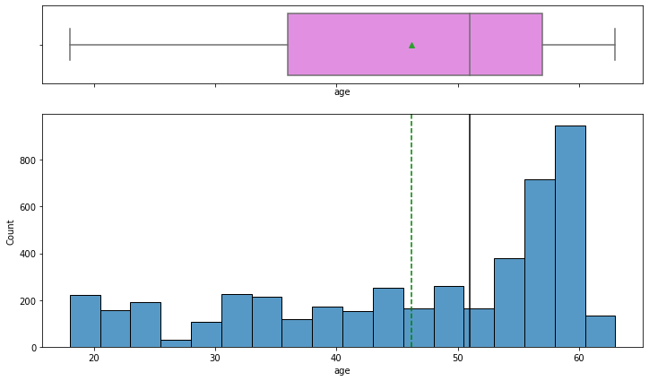

```python
histogram_boxplot(data, "age")
```

### Observations on website_visits

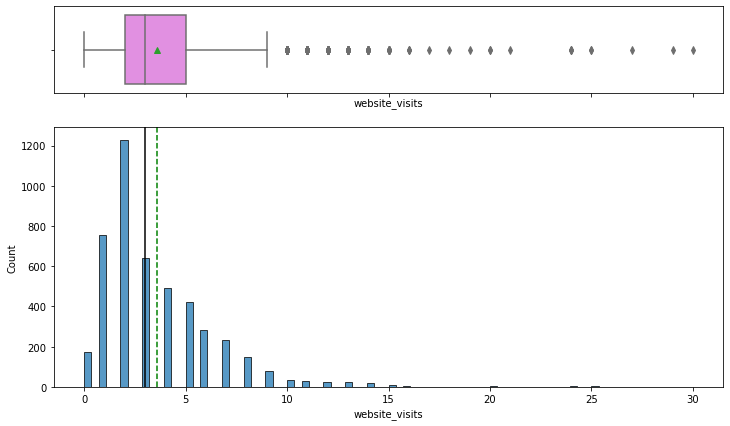

```python
histogram_boxplot(data, "website_visits")
```

```python
data[data["website_visits"] == 0].shape
```

```
(174, 14)
```

### Observations on number of time_spent_on_website

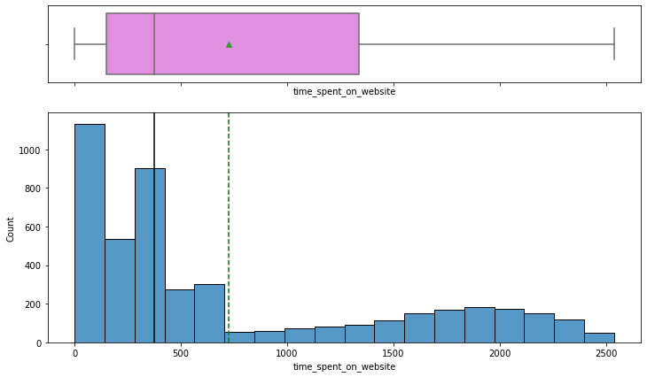

```python
histogram_boxplot(data, "time_spent_on_website")
```

### Observations on number of page_views_per_visit

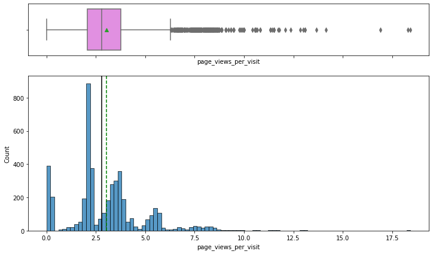

```python
histogram_boxplot(data, "page_views_per_visit")
```

```python
def labeled_barplot(data, feature, perc=False, n=None):
    """
    Barplot with percentage at the top

    data: dataframe
    feature: dataframe column
    perc: whether to display percentages instead of count (default is False)
    n: displays the top n category levels (default is None, i.e., display all levels)
    """

    total = len(data[feature])
    count = data[feature].nunique()
    if n is None:
        plt.figure(figsize=(count + 1, 5))
    else:
        plt.figure(figsize=(n + 1, 5))

    plt.xticks(rotation=90, fontsize=15)
    ax = sns.countplot(
        data=data,
        x=feature,
        palette="Paired",
        order=data[feature].value_counts().index[:n].sort_values(),
    )

    for p in ax.patches:
        if perc == True:
            label = "{:.1f}%".format(100 * p.get_height() / total)
        else:
            label = p.get_height()

        x = p.get_x() + p.get_width() / 2  # width of the plot
        y = p.get_height()

        ax.annotate(
            label,
            (x, y),
            ha="center",
            va="center",
            size=12,
            xytext=(0, 5),
            textcoords="offset points",
        )

    plt.show()
```

### Observations on current_occupation

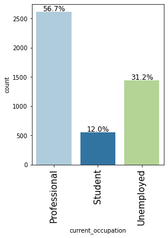

```python
labeled_barplot(data, "current_occupation", perc=True)
```

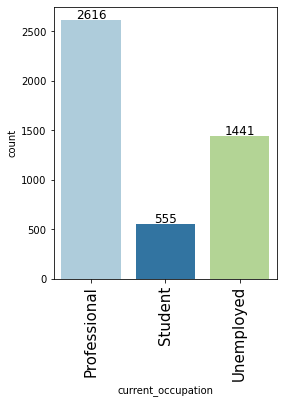

```python
labeled_barplot(data, "current_occupation")
```

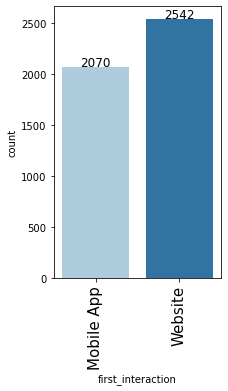

```python
labeled_barplot(data, "first_interaction")
```

### Observations on last_activity

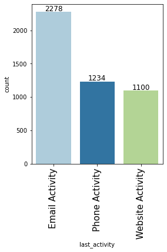

```python
labeled_barplot(data, "last_activity")
```

### Observations on print_media_type1

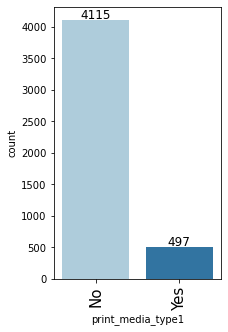

```python
labeled_barplot(data, "print_media_type1")
```

### Observations on print_media_type2

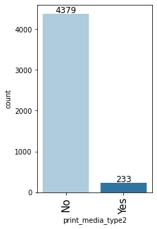

```python
labeled_barplot(data, "print_media_type2")
```

### Observations on digital_media

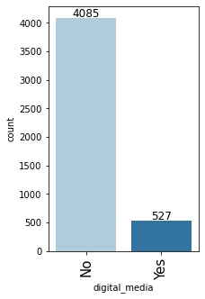

```python
labeled_barplot(data, "digital_media")
```

### Observations on educational_channels

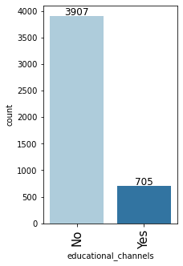

```python
labeled_barplot(data, "educational_channels")
```

### Observations on referral

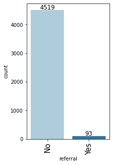

```python
labeled_barplot(data, "referral")
```

### Observations on status

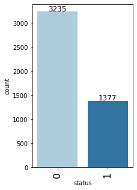

```python
labeled_barplot(data, "status")
```

### Bivariate Analysis

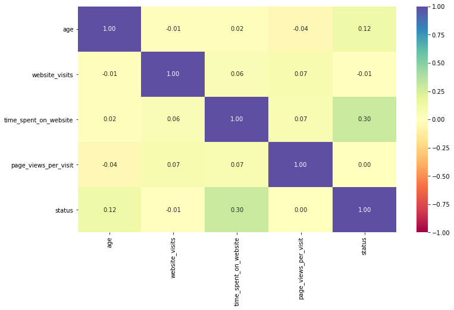

```python
cols_list = data.select_dtypes(include=np.number).columns.tolist()

plt.figure(figsize=(12, 7))
sns.heatmap(
    data[cols_list].corr(), annot=True, vmin=-1, vmax=1, fmt=".2f", cmap="Spectral"
)
plt.show()
```

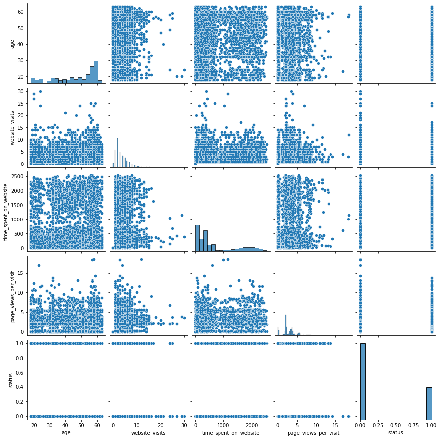

```python
sns.pairplot(data)
plt.show()
```

**Creating functions that will help us with further analysis.**

```python
def distribution_plot_wrt_target(data, predictor, target):

    fig, axs = plt.subplots(2, 2, figsize=(12, 10))

    target_uniq = data[target].unique()

    axs[0, 0].set_title("Distribution of target for target=" + str(target_uniq[0]))
    sns.histplot(
        data=data[data[target] == target_uniq[0]],
        x=predictor,
        kde=True,
        ax=axs[0, 0],
        color="teal",
        stat="density",
    )

    axs[0, 1].set_title("Distribution of target for target=" + str(target_uniq[1]))
    sns.histplot(
        data=data[data[target] == target_uniq[1]],
        x=predictor,
        kde=True,
        ax=axs[0, 1],
        color="orange",
        stat="density",
    )

    axs[1, 0].set_title("Boxplot w.r.t target")
    sns.boxplot(data=data, x=target, y=predictor, ax=axs[1, 0], palette="gist_rainbow")

    axs[1, 1].set_title("Boxplot (without outliers) w.r.t target")
    sns.boxplot(
        data=data,
        x=target,
        y=predictor,
        ax=axs[1, 1],
        showfliers=False,
        palette="gist_rainbow",
    )

    plt.tight_layout()
    plt.show()
```

```python
def stacked_barplot(data, predictor, target):
    """
    Print the category counts and plot a stacked bar chart

    data: dataframe
    predictor: independent variable
    target: target variable
    """
    count = data[predictor].nunique()
    sorter = data[target].value_counts().index[-1]
    tab1 = pd.crosstab(data[predictor], data[target], margins=True).sort_values(
        by=sorter, ascending=False
    )
    print(tab1)
    print("-" * 120)
    tab = pd.crosstab(data[predictor], data[target], normalize="index").sort_values(
        by=sorter, ascending=False
    )
    tab.plot(kind="bar", stacked=True, figsize=(count + 5, 5))
    plt.legend(
        loc="lower left", frameon=False,
    )
    plt.legend(loc="upper left", bbox_to_anchor=(1, 1))
    plt.show()
```

**Leads will have different expectations from the outcome of the course and the current occupation may play a key role for them to take the program. Let's analyze it**

```
status                 0     1   All
current_occupation
All                 3235  1377  4612
Professional        1687   929  2616
Unemployed          1058   383  1441
Student              490    65   555
------------------------------------------------------------------------------------------------------------------------
```

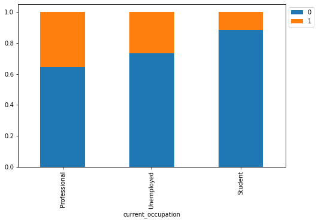

```python
stacked_barplot(data, "current_occupation", "status")
```

**Age can be a good factor to differentiate between such leads**

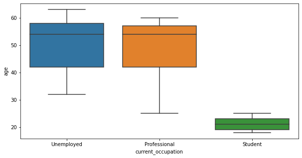

```python
plt.figure(figsize=(10, 5))
sns.boxplot(data["current_occupation"], data["age"])
plt.show()
```

```python
data.groupby(["current_occupation"])["age"].describe()
```

| current_occupation | count | mean | std | min | 25% | 50% | 75% | max |
| --- | --- | --- | --- | --- | --- | --- | --- | --- |
| Professional | 2616.00000 | 49.34748 | 9.89074 | 25.00000 | 42.00000 | 54.00000 | 57.00000 | 60.00000 |
| Student | 555.00000 | 21.14414 | 2.00111 | 18.00000 | 19.00000 | 21.00000 | 23.00000 | 25.00000 |
| Unemployed | 1441.00000 | 50.14018 | 9.99950 | 32.00000 | 42.00000 | 54.00000 | 58.00000 | 63.00000 |

**The company's first interaction with leads should be compelling and persuasive. Let's see if the channels of the first interaction have an impact on the conversion of leads**

```
status                0     1   All
first_interaction
All                3235  1377  4612
Website            1383  1159  2542
Mobile App         1852   218  2070
------------------------------------------------------------------------------------------------------------------------
```

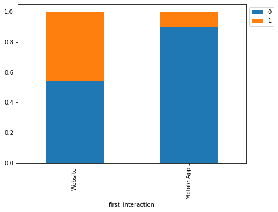

```python
stacked_barplot(data, "first_interaction", "status")
```

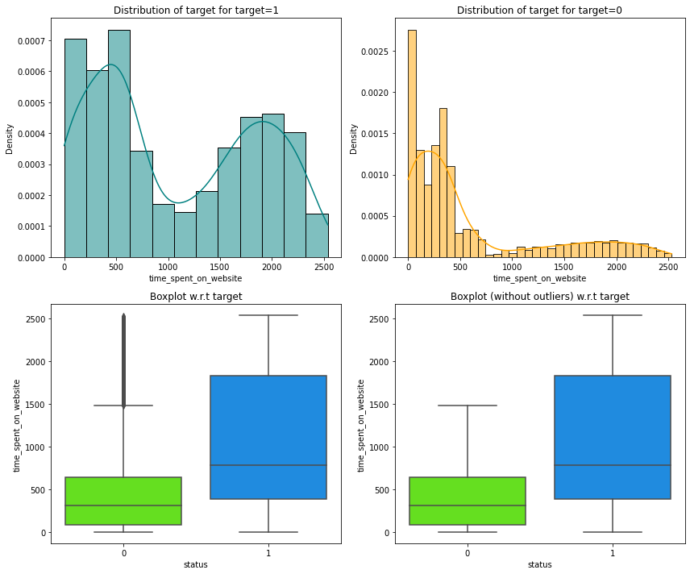

```python
distribution_plot_wrt_target(data, "time_spent_on_website", "status")
```

```python
data.groupby(["status"])["time_spent_on_website"].median()
```

```
status
0    317
1    789
Name: time_spent_on_website, dtype: int64
```

**People browsing the website or the mobile app are generally required to create a profile by sharing their personal details before they can access more information. Let's see if the profile completion level has an impact on lead status**

```
status                0     1   All
profile_completed
All                3235  1377  4612
High               1318   946  2264
Medium             1818   423  2241
Low                  99     8   107
------------------------------------------------------------------------------------------------------------------------
```

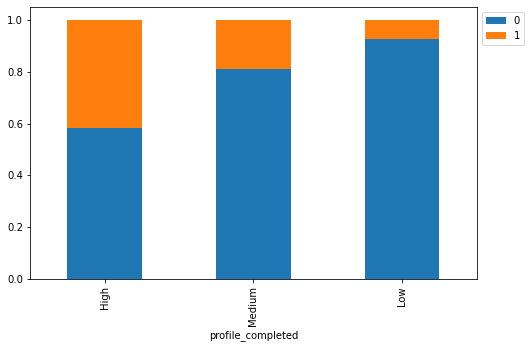

```python
stacked_barplot(data, "profile_completed", "status")
```

**After a lead shares their information by creating a profile, there may be interactions between the lead and the company to proceed with the process of enrollment. Let's see how the last activity impacts lead conversion status**

```
status               0     1   All
last_activity
All               3235  1377  4612
Email Activity    1587   691  2278
Website Activity   677   423  1100
Phone Activity     971   263  1234
------------------------------------------------------------------------------------------------------------------------
```

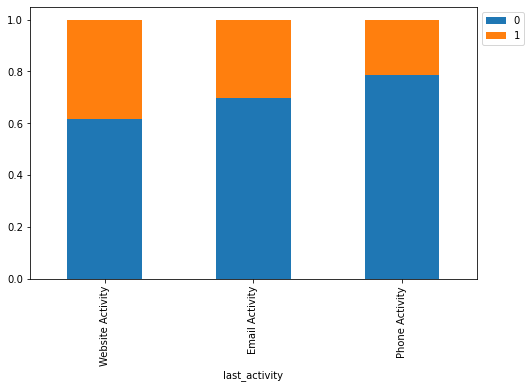

```python
stacked_barplot(data, "last_activity", "status")
```

**Let's see how advertisement and referrals impact the lead status**

```
status                0     1   All
print_media_type1
All                3235  1377  4612
No                 2897  1218  4115
Yes                 338   159   497
------------------------------------------------------------------------------------------------------------------------
```

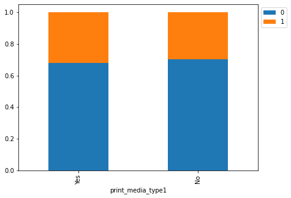

```python
stacked_barplot(data, "print_media_type1", "status")
```

```
status                0     1   All
print_media_type2
All                3235  1377  4612
No                 3077  1302  4379
Yes                 158    75   233
------------------------------------------------------------------------------------------------------------------------
```

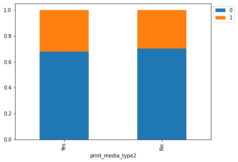

```python
stacked_barplot(data, "print_media_type2", "status")
```

```
status            0     1   All
digital_media
All            3235  1377  4612
No             2876  1209  4085
Yes             359   168   527
------------------------------------------------------------------------------------------------------------------------
```

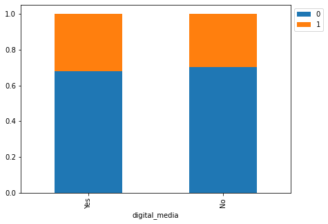

```python
stacked_barplot(data, "digital_media", "status")
```

```
status                   0     1   All
educational_channels
All                   3235  1377  4612
No                    2727  1180  3907
Yes                    508   197   705
------------------------------------------------------------------------------------------------------------------------
```

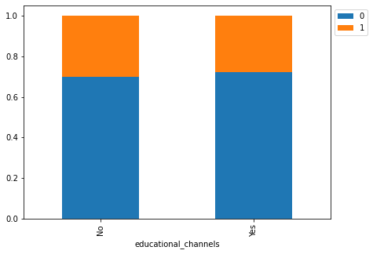

```python
stacked_barplot(data, "educational_channels", "status")
```

```
status       0     1   All
referral
All       3235  1377  4612
No        3205  1314  4519
Yes         30    63    93
------------------------------------------------------------------------------------------------------------------------
```

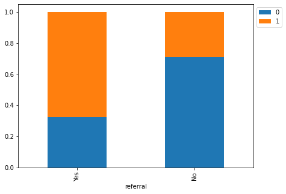

```python
stacked_barplot(data, "referral", "status")
```

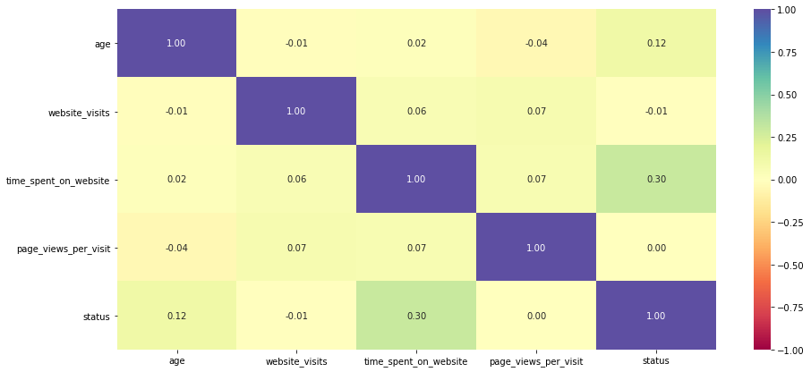

```python
plt.figure(figsize=(15, 7))
sns.heatmap(data.corr(), annot=True, vmin=-1, vmax=1, fmt=".2f", cmap="Spectral")
plt.show()
```

### Outlier Check

- Let's check for outliers in the data.

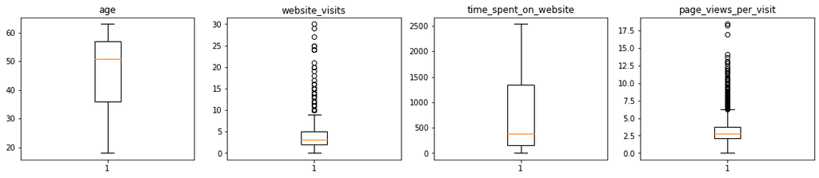

```python
numeric_columns = data.select_dtypes(include=np.number).columns.tolist()
numeric_columns.remove("status")

plt.figure(figsize=(15, 12))

for i, variable in enumerate(numeric_columns):
    plt.subplot(4, 4, i + 1)
    plt.boxplot(data[variable], whis=1.5)
    plt.tight_layout()
    plt.title(variable)

plt.show()
```

### Data Preparation for modeling

- We want to predict which lead is more likely to be converted.
- Before we proceed to build a model, we'll have to encode categorical features.
- We'll split the data into train and test to be able to evaluate the model that we build on the train data.

```python
X = data.drop(["status"], axis=1)
Y = data["status"]
X = pd.get_dummies(X, drop_first=True)

X_train, X_test, y_train, y_test = train_test_split(
    X, Y, test_size=0.30, random_state=1
)
```

```python
print("Shape of Training set : ", X_train.shape)
print("Shape of test set : ", X_test.shape)
print("Percentage of classes in training set:")
print(y_train.value_counts(normalize=True))
print("Percentage of classes in test set:")
print(y_test.value_counts(normalize=True))
```

```
Shape of Training set :  (3228, 16)
Shape of test set :  (1384, 16)
Percentage of classes in training set:
0   0.70415
1   0.29585
Name: status, dtype: float64
Percentage of classes in test set:
0   0.69509
1   0.30491
Name: status, dtype: float64
```

### Model evaluation criterion

### Model can make wrong predictions as:

1. Predicting a lead will not be converted to a paid customer in reality, the lead would have converted to a paid customer.
2. Predicting a lead will be converted to a paid customer in reality, the lead would not have converted to a paid customer.

### Which case is more important?

- If we predict that a lead will not get converted and the lead would have converted then the company will lose a potential customer.
- If we predict that a lead will get converted and the lead doesn't get converted the company might lose resources by nurturing false-positive cases.

Losing a potential customer is a greater loss.

### How to reduce the losses?

- Company would want `Recall` to be maximized, greater the Recall score higher are the chances of minimizing False Negatives.

#### First, let's create functions to calculate different metrics and confusion matrix so that we don't have to use the same code repeatedly for each model.

- The model_performance_classification_statsmodels function will be used to check the model performance of models.
- The confusion_matrix_statsmodels function will be used to plot the confusion matrix.

```python
def model_performance_classification_statsmodels(
    model, predictors, target, threshold=0.5
):
    """
    Function to compute different metrics to check classification model performance

    model: classifier
    predictors: independent variables
    target: dependent variable
    threshold: threshold for classifying the observation as class 1
    """

    pred_temp = model.predict(predictors) > threshold
    pred = np.round(pred_temp)

    acc = accuracy_score(target, pred)
    recall = recall_score(target, pred)
    precision = precision_score(target, pred)
    f1 = f1_score(target, pred)

    df_perf = pd.DataFrame(
        {"Accuracy": acc, "Recall": recall, "Precision": precision, "F1": f1,},
        index=[0],
    )

    return df_perf
```

```python
def confusion_matrix_statsmodels(model, predictors, target, threshold=0.5):
    """
    To plot the confusion_matrix with percentages

    model: classifier
    predictors: independent variables
    target: dependent variable
    threshold: threshold for classifying the observation as class 1
    """
    y_pred = model.predict(predictors) > threshold
    cm = confusion_matrix(target, y_pred)
    labels = np.asarray(
        [
            ["{0:0.0f}".format(item) + "\n{0:.2%}".format(item / cm.flatten().sum())]
            for item in cm.flatten()
        ]
    ).reshape(2, 2)

    plt.figure(figsize=(6, 4))
    sns.heatmap(cm, annot=labels, fmt="")
    plt.ylabel("True label")
    plt.xlabel("Predicted label")
```

### Logistic Regression (with statsmodels library)

```python
X = data.drop(["status"], axis=1)
Y = data["status"]


X = sm.add_constant(X)
X = pd.get_dummies(X, drop_first=True)

(X_train, X_test, y_train, y_test,) = train_test_split(
    X, Y, test_size=0.3, random_state=1
)
```

```python
logit = sm.Logit(y_train, X_train.astype(float))
lg = logit.fit(disp=False)

print(lg.summary())
```

```
                           Logit Regression Results
==============================================================================
Dep. Variable:                 status   No. Observations:                 3228
Model:                          Logit   Df Residuals:                     3211
Method:                           MLE   Df Model:                           16
Date:                Thu, 02 Jun 2022   Pseudo R-squ.:                  0.3589
Time:                        23:33:12   Log-Likelihood:                -1256.8
converged:                       True   LL-Null:                       -1960.4
Covariance Type:            nonrobust   LLR p-value:                4.576e-290
==================================================================================================
                                     coef    std err          z      P>|z|      [0.025      0.975]
--------------------------------------------------------------------------------------------------
const                             -2.3415      0.309     -7.580      0.000      -2.947      -1.736
age                               -0.0023      0.005     -0.443      0.657      -0.012       0.008
website_visits                    -0.0031      0.019     -0.169      0.865      -0.039       0.033
time_spent_on_website              0.0012   7.12e-05     17.558      0.000       0.001       0.001
page_views_per_visit              -0.0342      0.026     -1.301      0.193      -0.086       0.017
current_occupation_Student        -2.1984      0.254     -8.642      0.000      -2.697      -1.700
current_occupation_Unemployed     -0.5794      0.110     -5.244      0.000      -0.796      -0.363
first_interaction_Website          2.7226      0.127     21.498      0.000       2.474       2.971
profile_completed_Low             -2.4844      0.467     -5.323      0.000      -3.399      -1.570
profile_completed_Medium          -1.7699      0.109    -16.178      0.000      -1.984      -1.555
last_activity_Phone Activity      -0.6989      0.126     -5.562      0.000      -0.945      -0.453
last_activity_Website Activity     0.4660      0.120      3.880      0.000       0.231       0.701
print_media_type1_Yes              0.2258      0.154      1.469      0.142      -0.075       0.527
print_media_type2_Yes              0.4621      0.220      2.097      0.036       0.030       0.894
digital_media_Yes                  0.1142      0.155      0.737      0.461      -0.190       0.418
educational_channels_Yes           0.1286      0.144      0.892      0.372      -0.154       0.411
referral_Yes                       1.5923      0.379      4.198      0.000       0.849       2.336
==================================================================================================
```

```python
print("Training performance:")
model_performance_classification_statsmodels(lg, X_train, y_train)
```

```
Training performance:
```

|  | Accuracy | Recall | Precision | F1 |
| --- | --- | --- | --- | --- |
| 0 | 0.82776 | 0.66178 | 0.73064 | 0.69451 |

### Multicollinearity

```python
def checking_vif(predictors):
    vif = pd.DataFrame()
    vif["feature"] = predictors.columns

    vif["VIF"] = [
        variance_inflation_factor(predictors.values, i)
        for i in range(len(predictors.columns))
    ]
    return vif
```

```python
checking_vif(X_train)
```

|  | feature | VIF |
| --- | --- | --- |
| 0 | const | 38.00376 |
| 1 | age | 1.97547 |
| 2 | website_visits | 1.01606 |
| 3 | time_spent_on_website | 1.02318 |
| 4 | page_views_per_visit | 1.01711 |
| 5 | current_occupation_Student | 2.02624 |
| 6 | current_occupation_Unemployed | 1.07083 |
| 7 | first_interaction_Website | 1.00842 |
| 8 | profile_completed_Low | 1.03701 |
| 9 | profile_completed_Medium | 1.02992 |
| 10 | last_activity_Phone Activity | 1.13621 |
| 11 | last_activity_Website Activity | 1.14076 |
| 12 | print_media_type1_Yes | 1.00208 |
| 13 | print_media_type2_Yes | 1.00265 |
| 14 | digital_media_Yes | 1.00396 |
| 15 | educational_channels_Yes | 1.00517 |
| 16 | referral_Yes | 1.00847 |

### Dropping high p-value variables

- We will drop the predictor variables having a p-value greater than 0.05 as they do not significantly impact the target variable.
- But sometimes p-values change after dropping a variable. So, we'll not drop all variables at once.
- Instead, we will do the following:
  - Build a model, check the p-values of the variables, and drop the column with the highest p-value.
  - Create a new model without the dropped feature, check the p-values of the variables, and drop the column with the highest p-value.
  - Repeat the above two steps till there are no columns with p-value > 0.05.

The above process can also be done manually by picking one variable at a time that has a high p-value, dropping it, and building a model again. But that might be a little tedious and using a loop will be more efficient.

```python
cols = X_train.columns.tolist()

max_p_value = 1

while len(cols) > 0:
    x_train_aux = X_train[cols]

    model = sm.Logit(y_train, x_train_aux).fit(disp=False)

    p_values = model.pvalues
    max_p_value = max(p_values)

    feature_with_p_max = p_values.idxmax()

    if max_p_value > 0.05:
        cols.remove(feature_with_p_max)
    else:
        break

selected_features = cols
print(selected_features)
```

```
['const', 'time_spent_on_website', 'current_occupation_Student', 'current_occupation_Unemployed', 'first_interaction_Website', 'profile_completed_Low', 'profile_completed_Medium', 'last_activity_Phone Activity', 'last_activity_Website Activity', 'print_media_type2_Yes', 'referral_Yes']
```

```python
X_train1 = X_train[selected_features]
X_test1 = X_test[selected_features]
```

```python
logit1 = sm.Logit(y_train, X_train1.astype(float))
lg1 = logit1.fit(disp=False)
print(lg1.summary())


logit1 = sm.Logit(y_train, X_train1.astype(float))
lg1 = logit1.fit(disp=False)
print(lg1.summary())
```

```
                           Logit Regression Results
==============================================================================
Dep. Variable:                 status   No. Observations:                 3228
Model:                          Logit   Df Residuals:                     3217
Method:                           MLE   Df Model:                           10
Date:                Thu, 02 Jun 2022   Pseudo R-squ.:                  0.3576
Time:                        23:33:13   Log-Likelihood:                -1259.3
converged:                       True   LL-Null:                       -1960.4
Covariance Type:            nonrobust   LLR p-value:                3.443e-295
==================================================================================================
                                     coef    std err          z      P>|z|      [0.025      0.975]
--------------------------------------------------------------------------------------------------
const                             -2.4977      0.141    -17.732      0.000      -2.774      -2.222
time_spent_on_website              0.0012   7.06e-05     17.546      0.000       0.001       0.001
current_occupation_Student        -2.1419      0.204    -10.489      0.000      -2.542      -1.742
current_occupation_Unemployed     -0.5878      0.110     -5.336      0.000      -0.804      -0.372
first_interaction_Website          2.7178      0.126     21.518      0.000       2.470       2.965
profile_completed_Low             -2.4736      0.466     -5.306      0.000      -3.387      -1.560
profile_completed_Medium          -1.7612      0.109    -16.166      0.000      -1.975      -1.548
last_activity_Phone Activity      -0.6965      0.125     -5.560      0.000      -0.942      -0.451
last_activity_Website Activity     0.4629      0.120      3.867      0.000       0.228       0.698
print_media_type2_Yes              0.4616      0.220      2.101      0.036       0.031       0.892
referral_Yes                       1.6006      0.382      4.195      0.000       0.853       2.349
==================================================================================================
                           Logit Regression Results
==============================================================================
Dep. Variable:                 status   No. Observations:                 3228
Model:                          Logit   Df Residuals:                     3217
Method:                           MLE   Df Model:                           10
Date:                Thu, 02 Jun 2022   Pseudo R-squ.:                  0.3576
Time:                        23:33:13   Log-Likelihood:                -1259.3
converged:                       True   LL-Null:                       -1960.4
Covariance Type:            nonrobust   LLR p-value:                3.443e-295
==================================================================================================
                                     coef    std err          z      P>|z|      [0.025      0.975]
--------------------------------------------------------------------------------------------------
const                             -2.4977      0.141    -17.732      0.000      -2.774      -2.222
time_spent_on_website              0.0012   7.06e-05     17.546      0.000       0.001       0.001
current_occupation_Student        -2.1419      0.204    -10.489      0.000      -2.542      -1.742
current_occupation_Unemployed     -0.5878      0.110     -5.336      0.000      -0.804      -0.372
first_interaction_Website          2.7178      0.126     21.518      0.000       2.470       2.965
profile_completed_Low             -2.4736      0.466     -5.306      0.000      -3.387      -1.560
profile_completed_Medium          -1.7612      0.109    -16.166      0.000      -1.975      -1.548
last_activity_Phone Activity      -0.6965      0.125     -5.560      0.000      -0.942      -0.451
last_activity_Website Activity     0.4629      0.120      3.867      0.000       0.228       0.698
print_media_type2_Yes              0.4616      0.220      2.101      0.036       0.031       0.892
referral_Yes                       1.6006      0.382      4.195      0.000       0.853       2.349
==================================================================================================
```

```python
print("Training performance:")
model_performance_classification_statsmodels(
    lg1, X_train1, y_train
)
```

```
Training performance:
```

|  | Accuracy | Recall | Precision | F1 |
| --- | --- | --- | --- | --- |
| 0 | 0.82714 | 0.65969 | 0.73001 | 0.69307 |